# 2026 Spring BIO 2100 Final Creation and Answers

## 4

The dataset also gave a chance to consider how social the rays are. Scientists considered images of each sex to determine if they were photographed alone or in groups.

|  | Male | Female | Unknown |
| --- | --- | --- | --- |
| **Alone** | 38 | 6 | 14 |
| **In a group** | 4 | 22 | 49 |

Use the data to determine if sociality differs among sexes. Make sure you include (6 points)

- null hypothesis (1 point)
- H<sub>0</sub>: Ray sociality does not differ by sex
- alternative hypothesis (1 point)
- H<sub>0</sub>: Ray sociality does differ by sex
- explanation for test you will use (1.5 point)
- results from statistical test (1 point)
- I will attempt to use a $\chi^2$ test to compare proportions among the groups.

```r
ray_ratio_table <- matrix(c(38, 6, 14, 4,22,49), 2,3, byrow = T)
colnames(ray_ratio_table) <- c("male", "female", "unknown")
rownames(ray_ratio_table) <- c("alone", "group")
chisq.test(ray_ratio_table)
```

```
    Pearson's Chi-squared test

data:  ray_ratio_table
X-squared = 54.834, df = 2, p-value = 1.239e-12
```

Test assumptions appear to be met (no warnings). The p-value is <. 05 ($\chi^2_2$=54.834, p<.001, so I reject the null hypothesis. I carry out post-hoc tests to see which groups are different than others.I will use the Holm’s methods to adjust for FWER.

```r
library(rcompanion)
holm_correct <- pairwiseNominalIndependence(ray_ratio_table, compare="col", method = "holm")
library(rmarkdown)
paged_table(holm_correct[order(holm_correct$p.adj.Chisq), c("Comparison", "p.adj.Chisq")])
```

|  | Comparison | p.adj.Chisq |
| --- | --- | --- |
| 2 | male : unknown | 8.58e-11 |
| 1 | male : female | 4.18e-08 |
| 3 | female : unknown | 1.00e+00 |

- clear explanation of how results relate to your stated hypotheses (1.5 point)
- results indicate that males are diffent than the other groups (all p<.05). ## 5

Ornate eagle rays have very long tails - they can be up to 2-3 m long. A few images were found that allowed both the tail and the wing width to be measured. Is there any relationship among these body parts? Data is available at

```r
wing_tail_data <- read.csv("wing_tail_data.csv", stringsAsFactors = T)
```

Make sure you include (6 points)

- null hypothesis (1 point)
- H<sub>0</sub>: There is no relationship between tail length and wing width ($\beta=0$)
- alternative hypothesis (1 point)
- H<sub>0</sub>: There is no relationship between tail length and wing width ($\beta\neq0$)
- explanation for test you will use (1.5 point)
- I will use linear regression to compare the relationship between two continuous variables. I could also use/call this correlation and investigate correlation if I preferred.
- results from statistical test (1 point)

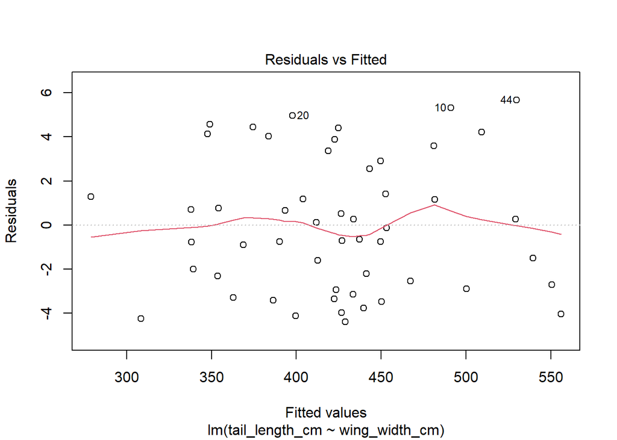

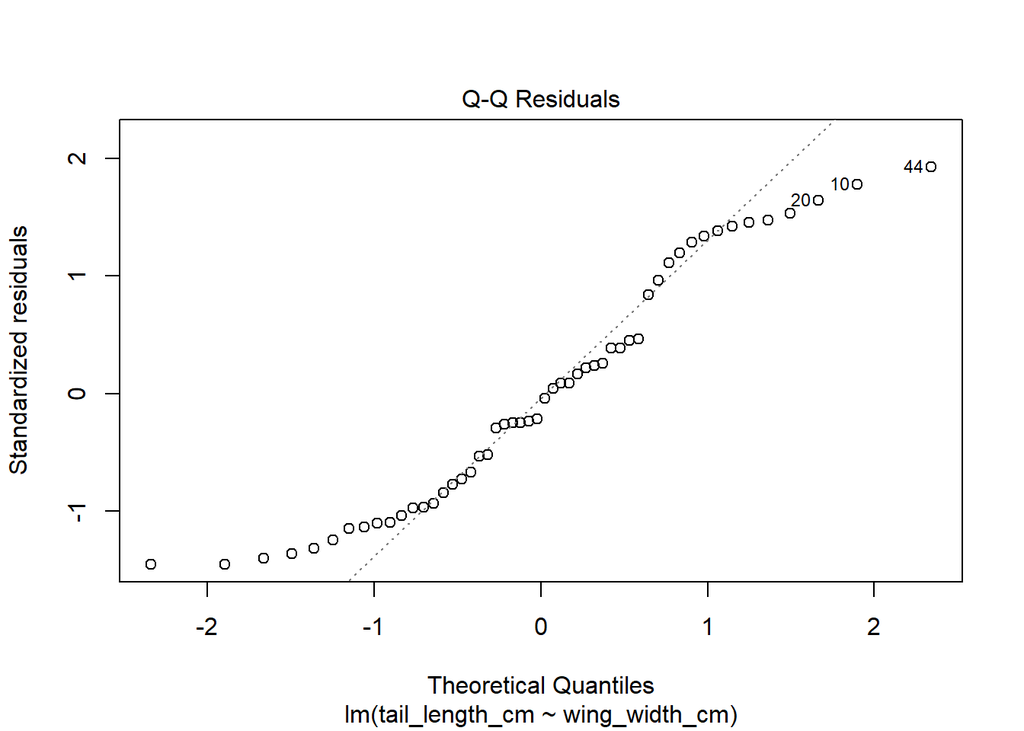

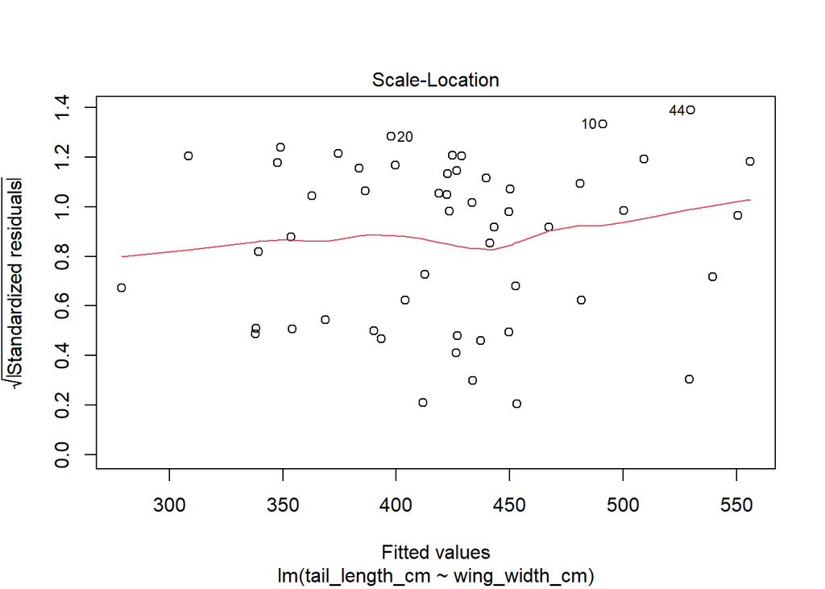

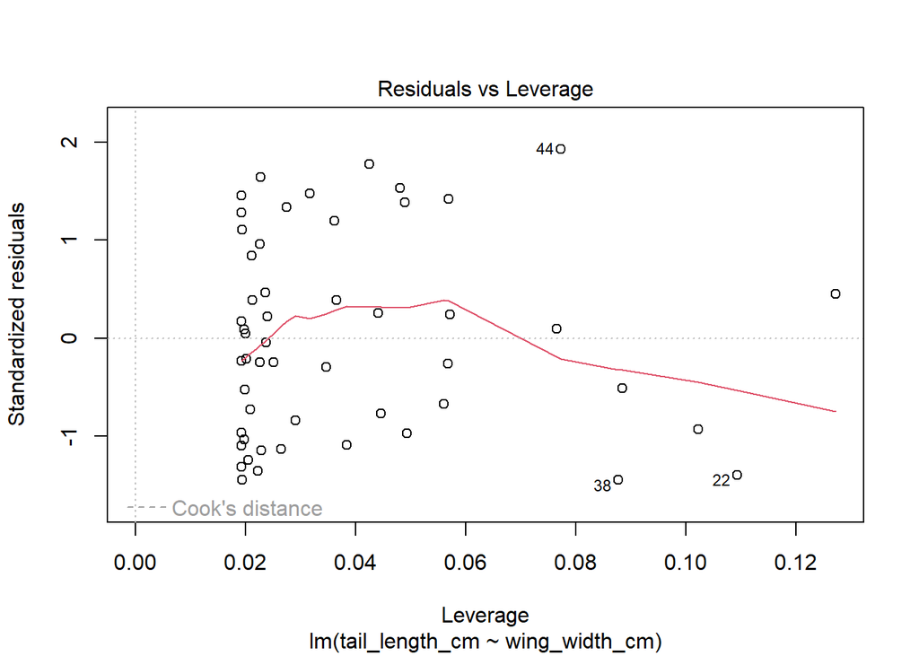

```r
plot(lm(tail_length_cm~wing_width_cm, wing_tail_data))
```

Assumptions appear to be met.

```r
summary(lm(tail_length_cm~wing_width_cm, wing_tail_data))
```

```
Call:
lm(formula = tail_length_cm ~ wing_width_cm, data = wing_tail_data)

Residuals:
    Min      1Q  Median      3Q     Max
-4.3946 -2.7486 -0.3866  2.6373  5.6681

Coefficients:
              Estimate Std. Error t value Pr(>|t|)
(Intercept)    5.67504    2.93163   1.936   0.0586 .
wing_width_cm  2.39333    0.01661 144.113   <2e-16 ***
---
Signif. codes:  0 '***' 0.001 '**' 0.01 '*' 0.05 '.' 0.1 ' ' 1

Residual standard error: 3.059 on 50 degrees of freedom
Multiple R-squared:  0.9976,    Adjusted R-squared:  0.9976
F-statistic: 2.077e+04 on 1 and 50 DF,  p-value: < 2.2e-16
```

or

```r
cor.test(~tail_length_cm+wing_width_cm, wing_tail_data)
```

```
    Pearson's product-moment correlation

data:  tail_length_cm and wing_width_cm
t = 144.11, df = 50, p-value < 2.2e-16
alternative hypothesis: true correlation is not equal to 0
95 percent confidence interval:
 0.9978974 0.9993135
sample estimates:
      cor
0.9987984
```

- clear explanation of how results relate to your stated hypotheses (1.5 point)
- Results indicate that there is a significant positive correlation between tail length and wing width (F<sub>1,50</sub>=20770, p<.005).I reject the null hypothesis.

## 6

In general, do you see any issues with using this data or the analysis you completed? Please note at least potential concerns or issues with any of the above datasets or analysis.

Issues include these being from uncontrolled photos, so maybe more at day than night, in touristy areas, or of extreme (large,small, colorful) rays.

## References

Araujo, Gonzalo, Christine Legaspi, Kinsey Matthews, Alessandro Ponzo, Andrew Chin, and B. Mabel Manjaji-Matsumoto. 2020. “Citizen science sheds light on the cryptic ornate eagle ray Aetomylaeus vespertilio.” *Aquatic Conservation* 30 (10): 2012–18. https://doi.org/10.1002/aqc.3457.

Gosnell, J Stephen. 2023. “What Is Community Science, and How Do I Get Involved?” *Lessons in Conservation* 13: 38–43.